# Wolverine 2017 to 2022 Comparison

Brian D. Gerber and Jacob S. Ivan

2025-05-20

# **Context**

Our goal is to make a direct comparison in predicted wolverine occupancy from the two surveys, 2017 and 2022. To do so, we will limit the comparison to only the shared sampling frame between the two surveys. The approach we are taking is different than used in the most recent draft manuscript.

In the draft, occupancy differences are estimated from a non-spatial occupancy. This approach is in contradiction to the utility of the spatial occupancy model, which is primarily aimed at predicting occurrence, leveraging the spatial patterns of detections and non-detections. The non-spatial model (w/o really good covariates) would have a higher likelihood of predicting wolverine occurrence in areas there are no detections.

Here, we estimate changes in occupancy between 2017 and 2022 by matching up the predicted realized occupancy site by site from the fitted spatial occupancy models for 2017 and 2022. This provides a direct comparison from two purposeful predictive models. Below we will do this two ways: 1) comparing occupancy predictions for the entire sampling frame that is shared b/w the two surveys and 2) comparing only at the cells that were surveyed in both surveys. The first way leverages the power of the statistical model and predictions, while the second way is more conservative and focused only where there is data. The results of these two ways are separated into separate sections.

## **Summary of Wolverine Detections by State**

For context, lets first summarize the total number of wolverine detections by state and then look at the naive occupancy; this will help in understanding the below predicted occupancy results between years. This summary will not be limited to to only the shared survey cells b/w years; it includes all surveyed cells in each year.

**2017 detections (1) and non-detections (0; rows) by state (columns):**

|  | Idaho | Montana | Washington | Wyoming |
| --- | --- | --- | --- | --- |
| 0 | 43 | 27 | 17 | 45 |
| 1 | 20 | 21 | 9 | 6 |

**2022 detections (1) and non-detections (0; rows) by state (columns):**

|  | Colorado | Idaho | Montana | Oregon | Utah | Washington | Wyoming |
| --- | --- | --- | --- | --- | --- | --- | --- |
| 0 | 16 | 39 | 38 | 16 | 15 | 22 | 38 |
| 1 | 0 | 20 | 8 | 0 | 0 | 3 | 13 |

**The naive occupancy by state for 2017:**

|  | x |
| --- | --- |
| Idaho | 0.317 |
| Montana | 0.438 |
| Washington | 0.346 |
| Wyoming | 0.118 |

**The naive occupancy by state for 2022:**

|  | x |
| --- | --- |
| Colorado | 0.000 |
| Idaho | 0.339 |
| Montana | 0.174 |
| Oregon | 0.000 |
| Utah | 0.000 |
| Washington | 0.120 |
| Wyoming | 0.255 |

# **Direct Comparisons b/w 2017 and 2022**

## **Sampling Frame Comparison**

Below I summed the latent state occupancy for all sites/cells within the shared sampling frame to derive a probability distribution of the total number of occupied sites (left plot) and the overall probability of occupancy (right plot) for each survey.

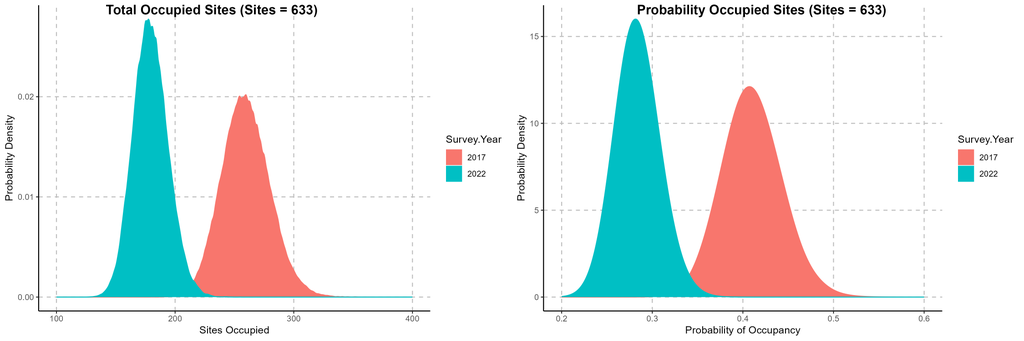

The probability of a decrease in total occupancy (from shared sampling frame) is 1.

The derived posterior probability distribution for the difference in number of occupied cells between 2022 and 2017 is shown below.

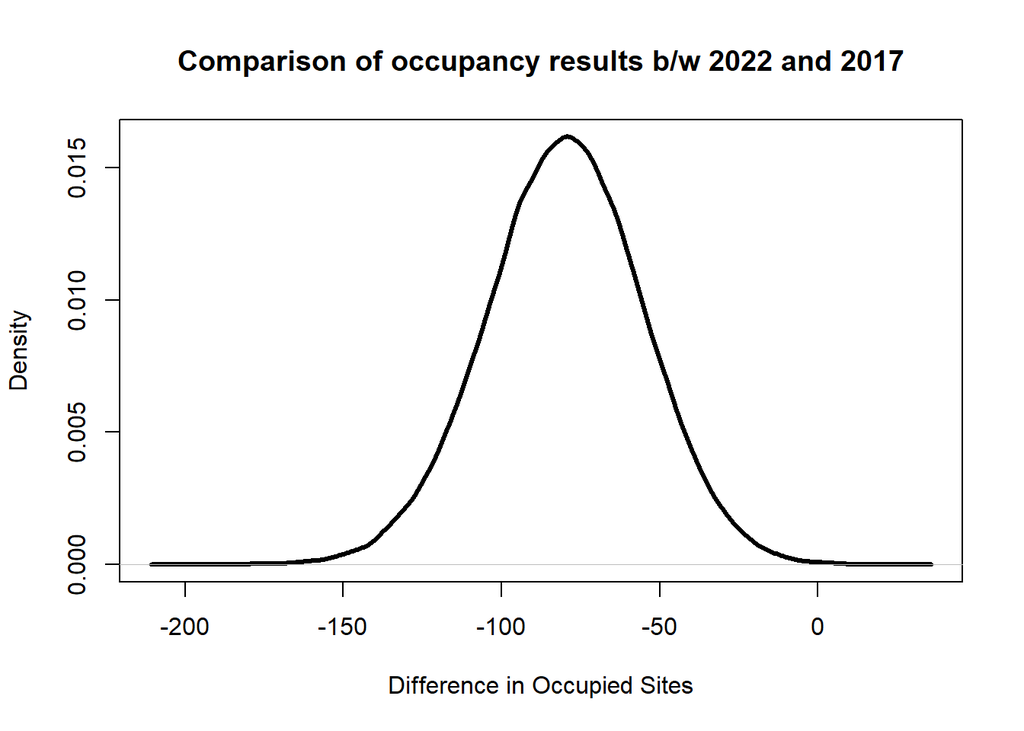

The posterior quantities for the difference in the number of cells is

|  | x |
| --- | --- |
| 2.5% | -130 |
| 50% | -80 |
| 97.5% | -32 |

### *State Comparison*

Next, we can compare the posterior distribution of the probability of occupancy between the two surveys by state.

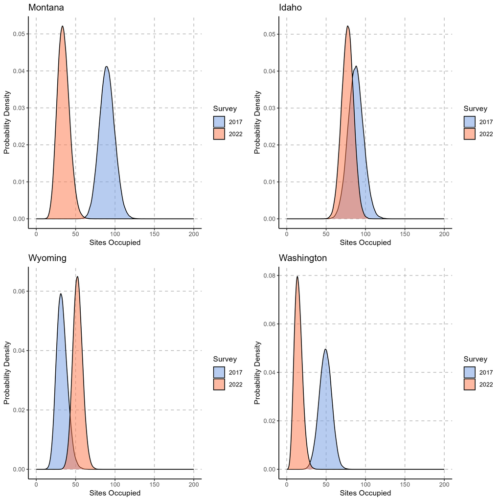

The posterior quantities of the probability of occupancy for each state and survey:

| Survey | State | 2.5% | 50% | 97.5% |
| --- | --- | --- | --- | --- |
| 2017 | WY | 21 | 32 | 47 |
| 2022 | WY | 41 | 52 | 65 |
| 2017 | MT | 72 | 90 | 109 |
| 2022 | MT | 21 | 34 | 51 |
| 2017 | ID | 69 | 88 | 107 |
| 2022 | ID | 62 | 77 | 92 |
| 2017 | WA | 33 | 49 | 65 |
| 2022 | WA | 6 | 14 | 26 |

### *Site Prediction Differences*

Here are the mean differences in the probability of occupancy between sites in 2022 and 2017.

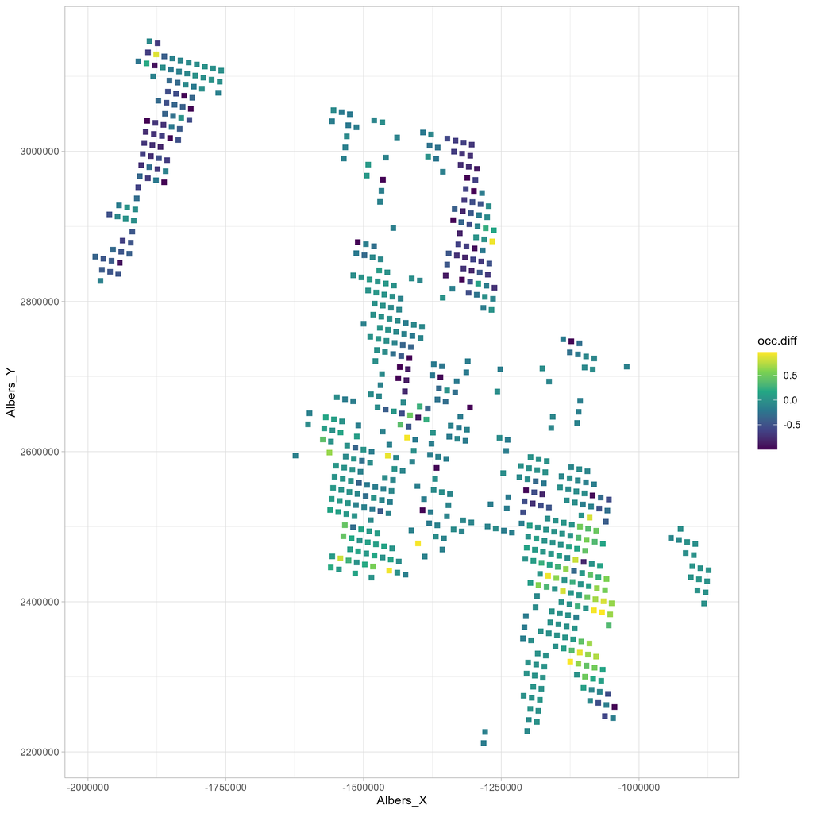

## **Surveyed Site Only Comparison**

Below we used the summed latent state occupancy for all sites/cells within the shared sampling frame to derive a probability distribution of the total number of occupied sites (left plot) and the overall probability of occupancy (right plot) for each survey.

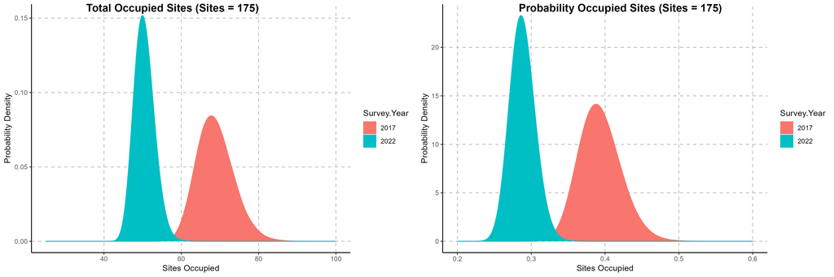

The probability of a decrease in total occupancy (from shared sampling frame) is 1`.

The derived posterior probability distribution for the difference in number of occupied cells between 2022 and 2017 is shown below.

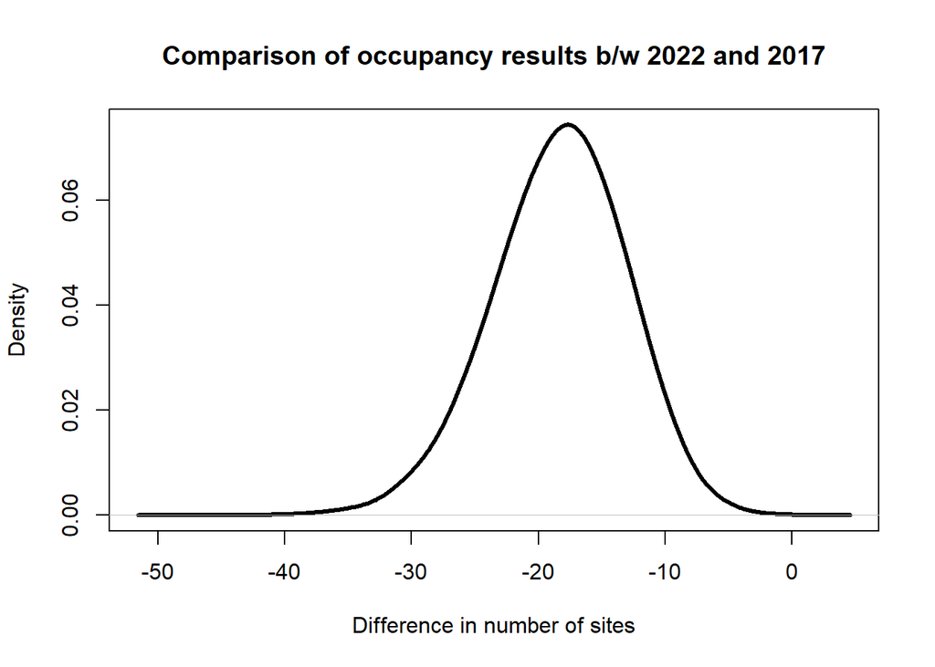

The posterior quantities for the number of cells is

|  | x |
| --- | --- |
| 2.5% | -30 |
| 50% | -18 |
| 97.5% | -9 |

### *State Comparison*

Next, we can compare the posterior distribution of the probability of occupancy between the two surveys by state.

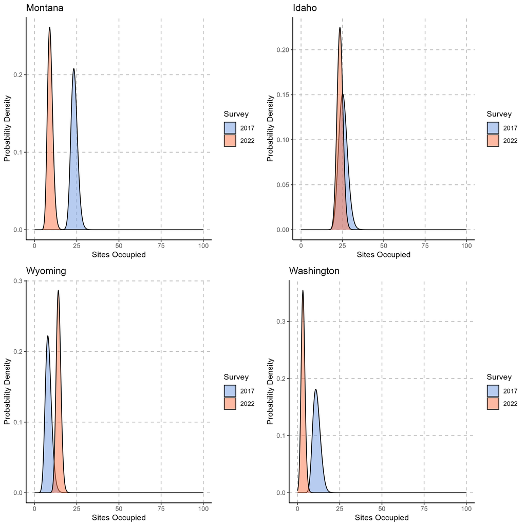

The posterior quantities of the probability of occupancy for each state and survey:

| Survey | State | 2.5% | 50% | 97.5% |
| --- | --- | --- | --- | --- |
| 2017 | WY | 6 | 8 | 12 |
| 2022 | WY | 13 | 14 | 16 |
| 2017 | MT | 21 | 23 | 27 |
| 2022 | MT | 8 | 9 | 12 |
| 2017 | ID | 21 | 25 | 31 |
| 2022 | ID | 21 | 24 | 27 |
| 2017 | WA | 8 | 11 | 16 |
| 2022 | WA | 3 | 3 | 5 |

### *Site Prediction Differences*

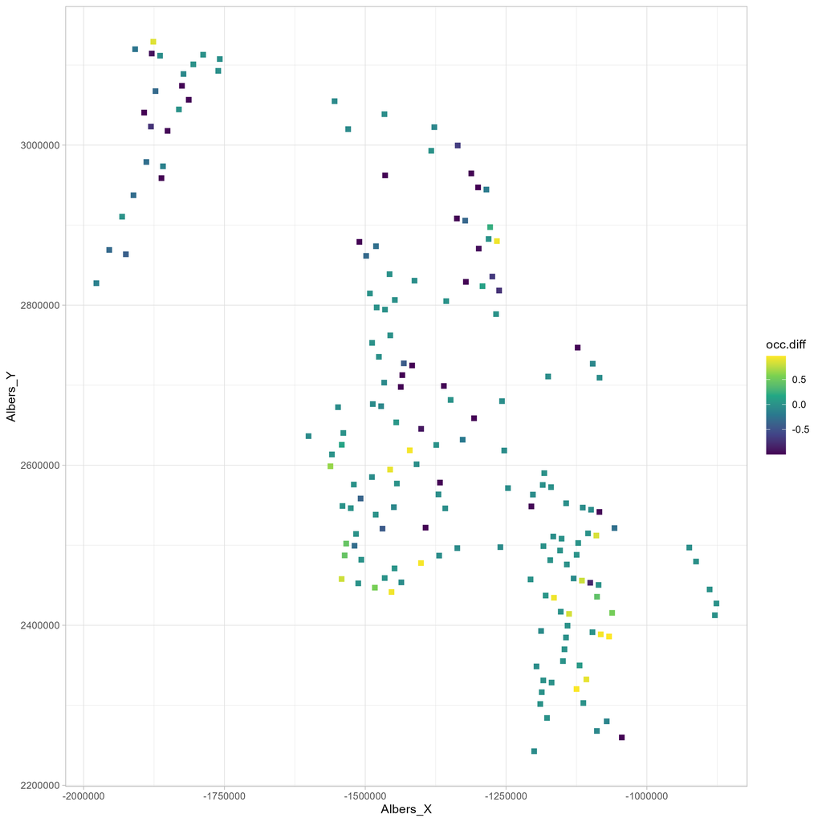